# The complement’s field block across the MR simulation cells

- Show All Code
- Hide All Code
- View Source

One-sided UPPER-bound and two-sided coverage of β(Ĥᶜ) against residual bias, with the Gaussian reference (TASK_mr_field_complement_2026-09-06)

Author

Larry León

Published

September 6, 2026

Selection acts on the harm-subgroup effects; the complement $\widehat H^{c}$ is its by-product, and its naive estimate is pushed toward *benefit*. For a benefit claim (“HR in $\widehat H^{c}$ is at most $U$”) the exposed limit is the **upper** bound on the complement’s log-HR, so the one-sided read here is $\beta(\widehat H^{c}) \le U$ and the Gaussian bookkeeping reference is $\Phi(z_{0.95} r + b)$ (a positive retained bias helps an upper bound where it hurts a lower one); two-sided coverage keeps $\Phi(z_{0.975} r - b) - \Phi(-z_{0.975} r - b)$. Cells are the `field_complement = TRUE` campaigns `s7c` / `map1c`, the same replicates as the committed `s7` / `map1` bundles (every non-complement-field column identical; Gate 2 record).

# 1 Knobs

```r
library(forestsearch)
library(ggplot2)
library(kableExtra)
globs <- strsplit(Sys.getenv("FS_SUMC_GLOBS",
                  "results/fs_*_s7c_combined_1_2000.rds;results/fs_*_map1c_combined_1_2000.rds"),
                  ";", fixed = TRUE)[[1]]
estimators <- c("mr", "fld")
curves     <- c(1, 1.25, 1.5, 2)
cell_label <- function(meta, f) {
  hr <- meta$target_hr_harm
  base <- if (hr < 1) sprintf("protective %.2f", hr)
  else if (hr == 1) "null 1.0" else sprintf("harm %.4g", hr)
  kn <- as.integer(sub("^.*_knoise(\\d+)_.*$", "\\1", basename(f)))
  nn <- if (meta$n_sample == 500) if (kn > 0 || hr < 1) "" else ", n=500" else sprintf(", n=%d", meta$n_sample)
  paste0(base, nn, if (kn > 0) sprintf(", %d noise", kn) else "")
}
```

# 2 Cells

```r
files <- sort(unlist(lapply(globs, Sys.glob)))
stopifnot(length(files) > 0)
tab <- do.call(rbind, lapply(files, function(f) {
  b <- readRDS(f)
  s <- fs_sim_bias_coverage(b$results, block = "Hc", estimators = estimators,
                            side = "upper")
  s$cell <- cell_label(b$meta, f); s$bundle <- basename(f); s
}))
tab$estimator <- factor(tab$estimator, levels = c("naive", "mr", "fld"),
                        labels = c("naive", "IJ", "field"))
kbl(tab[, c("cell", "estimator", "n", "b", "r", "cov1", "cov1_wilson_lo",
            "cov1_wilson_hi", "cov2", "cov2_wilson_lo", "cov2_wilson_hi",
            "cov1_ref", "cov2_ref")],
    digits = 3, booktabs = TRUE, row.names = FALSE,
    caption = "Complement block; cov1 = one-sided 95% UPPER-bound coverage of beta(Hhat^c).") |>
  kable_styling(font_size = 12)
```

Complement block; cov1 = one-sided 95% UPPER-bound coverage of beta(Hhat^c).

| cell | estimator | n | b | r | cov1 | cov1_wilson_lo | cov1_wilson_hi | cov2 | cov2_wilson_lo | cov2_wilson_hi | cov1_ref | cov2_ref |
| --- | --- | --- | --- | --- | --- | --- | --- | --- | --- | --- | --- | --- |
| protective 0.75 | IJ | 1042 | -0.123 | 1.843 | 0.995 | 0.989 | 0.998 | 1.000 | 0.996 | 1.000 | 0.998 | 1.000 |
| protective 0.75 | field | 1042 | -0.039 | 0.960 | 0.936 | 0.919 | 0.949 | 0.943 | 0.928 | 0.956 | 0.938 | 0.940 |
| null 1.0, n=1000 | IJ | 1319 | 0.004 | 1.854 | 0.998 | 0.993 | 0.999 | 1.000 | 0.997 | 1.000 | 0.999 | 1.000 |
| null 1.0, n=1000 | field | 1319 | 0.077 | 0.958 | 0.953 | 0.940 | 0.963 | 0.945 | 0.932 | 0.956 | 0.951 | 0.939 |
| null 1.0, n=500 | IJ | 1361 | -0.156 | 1.854 | 0.997 | 0.992 | 0.999 | 1.000 | 0.997 | 1.000 | 0.998 | 1.000 |
| null 1.0, n=500 | field | 1361 | -0.069 | 0.966 | 0.930 | 0.915 | 0.943 | 0.950 | 0.937 | 0.960 | 0.936 | 0.941 |
| harm 1.5, n=1500 | IJ | 1976 | 0.081 | 1.837 | 0.999 | 0.996 | 1.000 | 0.999 | 0.996 | 1.000 | 0.999 | 1.000 |
| harm 1.5, n=1500 | field | 1976 | 0.081 | 0.941 | 0.956 | 0.947 | 0.965 | 0.946 | 0.936 | 0.955 | 0.948 | 0.934 |
| harm 1.5, n=500 | IJ | 1822 | -0.105 | 1.813 | 0.997 | 0.993 | 0.998 | 1.000 | 0.998 | 1.000 | 0.998 | 1.000 |
| harm 1.5, n=500 | field | 1822 | -0.036 | 0.938 | 0.936 | 0.924 | 0.947 | 0.935 | 0.923 | 0.946 | 0.934 | 0.934 |
| harm 1.75, n=500 | IJ | 1900 | -0.058 | 1.800 | 0.999 | 0.996 | 1.000 | 1.000 | 0.998 | 1.000 | 0.998 | 1.000 |
| harm 1.75, n=500 | field | 1900 | -0.004 | 0.927 | 0.936 | 0.924 | 0.946 | 0.934 | 0.922 | 0.944 | 0.936 | 0.931 |
| harm 1.75, 3 noise | IJ | 1311 | -0.079 | 1.833 | 0.998 | 0.994 | 1.000 | 1.000 | 0.997 | 1.000 | 0.998 | 1.000 |
| harm 1.75, 3 noise | field | 1311 | -0.012 | 0.945 | 0.937 | 0.923 | 0.949 | 0.937 | 0.922 | 0.949 | 0.938 | 0.936 |

# 3 The display (block Ĥᶜ, side upper)

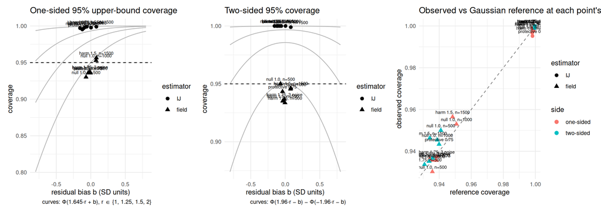

```r
fs_plot_bias_coverage(tab, curves = curves, side = "upper")
```

# 4 Reading

Across the 14 (cell, estimator) points the Gaussian reference at each point’s own (b, r) explains the one-sided upper coverage to within 0.008 (mean |gap| 0.002) and the two-sided coverage to within 0.012 (mean |gap| 0.003). Field rows: one-sided upper coverage 0.936/0.953/0.930/0.956/0.936/0.936/0.937 (Wilson intervals in the table), r = 0.96/0.96/0.97/0.94/0.94/0.93/0.94; IJ rows: coverage 0.995/0.998/0.997/0.999/0.997/0.999/0.998, r = 1.84/1.85/1.85/1.84/1.81/1.80/1.83.